# SDS 315 HW 8

Suryabh Singh

2025-04-14

## Suryabh Singh

**Suryabh Singh** **ss229756** **GitHub Repository:** [GitHub Link](https://github.com/singhsuryabh/SDS-315-HW-8)

#Upload Dataset

```r
library(ggplot2)
library(dplyr)
set.seed(123)
creatinine <- read.csv("/Users/suryabhsingh/Desktop/SDS 315/creatinine.csv")
```

##**Problem 1**

**Part A**

Regression Equation = 147.813 - 0.620 * (age)

Plug in age 55 into the regression equation: 147.813 - 0.620 * (55) = 113.71 mL/min

I used the regression formula derived from the data to predict the clearance rate by substituting age = 55 into the equation. This gives an expected rate of 113.71 mL/min.

**Part B** The slope of the regression line tells us the average change in clearance per year of age.

Slope = -0.620 mL/min per year

40 Year Old: 147.813 - 0.620 * 40 = 123.01 Residual = 135 - 123.01 = +11.99

##**Problem 2**

```r
library(ggplot2)
library(dplyr)
set.seed(123)
covid <- read.csv("/Users/suryabhsingh/Desktop/SDS 315/covid.csv")
```

**Fitting Models**

```r
fit_model <- function(data) {
  data <- data %>%
    mutate(log_deaths = log(deaths))

  model <- lm(log_deaths ~ days_since_first_death, data = data)
  growth_rate <- coef(model)[2]
  doubling_time <- log(2) / growth_rate

  list(model = model, growth_rate = growth_rate, doubling_time = doubling_time)
}

italy_data <- filter(covid, country == "Italy")
spain_data <- filter(covid, country == "Spain")

italy_model <- fit_model(italy_data)
spain_model <- fit_model(spain_data)
```

**Growth Rate and Doubling Time**

```r
cat("**Italy**\n")
```

```
## **Italy**
```

```r
cat("Growth Rate:", round(italy_model$growth_rate, 3), "\n")
```

```
## Growth Rate: 0.183
```

```r
cat("Doubling Time:", round(italy_model$doubling_time, 1), "days\n\n")
```

```
## Doubling Time: 3.8 days
```

```r
cat("**Spain**\n")
```

```
## **Spain**
```

```r
cat("Growth Rate:", round(spain_model$growth_rate, 3), "\n")
```

```
## Growth Rate: 0.276
```

```r
cat("Doubling Time:", round(spain_model$doubling_time, 1), "days\n")
```

```
## Doubling Time: 2.5 days
```

**95% Confidence Interval - Italy**

```r
bootstrap_ci <- function(data, n = 1000) {
  boot_rates <- numeric(n)
  boot_doublings <- numeric(n)

  for (i in 1:n) {
    boot <- data %>% sample_frac(replace = TRUE)
    model <- lm(log(deaths) ~ days_since_first_death, data = boot)
    r <- coef(model)[2]
    boot_rates[i] <- r
    boot_doublings[i] <- log(2) / r
  }

  list(
    growth_ci = quantile(boot_rates, c(0.025, 0.975)),
    doubling_ci = quantile(boot_doublings, c(0.025, 0.975))
  )
}

italy_ci <- bootstrap_ci(italy_data)

cat("**Italy – 95% Confidence Intervals**\n")
```

```
## **Italy – 95% Confidence Intervals**
```

```r
cat("Growth Rate CI:", round(italy_ci$growth_ci, 3), "\n")
```

```
## Growth Rate CI: 0.159 0.208
```

```r
cat("Doubling Time CI:", round(italy_ci$doubling_ci, 1), "\n")
```

```
## Doubling Time CI: 3.3 4.3
```

**95% Confidence Interval - Spain**

```r
spain_ci <- bootstrap_ci(spain_data)

cat("**Spain – 95% Confidence Intervals**\n")
```

```
## **Spain – 95% Confidence Intervals**
```

```r
cat("Growth Rate CI:", round(spain_ci$growth_ci, 3), "\n")
```

```
## Growth Rate CI: 0.238 0.318
```

```r
cat("Doubling Time CI:", round(spain_ci$doubling_ci, 1), "\n")
```

```
## Doubling Time CI: 2.2 2.9
```

**Line Graph of Daily Reported Deaths Over Time**

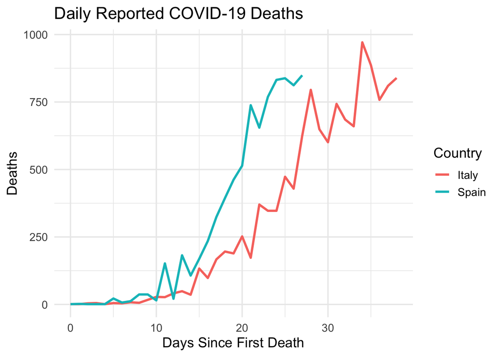

```r
ggplot(covid, aes(x = days_since_first_death, y = deaths, color = country)) +
  geom_line(size = 1.1) +
  labs(
    title = "Daily Reported COVID-19 Deaths",
    x = "Days Since First Death",
    y = "Deaths",
    color = "Country"
  ) +
  theme_minimal(base_size = 14)
```

##**Problem 3**

```r
library(ggplot2)
library(dplyr)
set.seed(123)
 milk <- read.csv("/Users/suryabhsingh/Desktop/SDS 315/milk.csv")
```

**95% Bootstrapped Confidence Interval**

```r
set.seed(42)

bootstrap_elasticity <- function(data, n = 1000) {
  boot_estimates <- numeric(n)

  for (i in 1:n) {
    boot_sample <- data %>%
      sample_frac(replace = TRUE) %>%
      mutate(
        log_price = log(price),
        log_sales = log(sales)
      )

    boot_model <- lm(log_sales ~ log_price, data = boot_sample)
    boot_estimates[i] <- coef(boot_model)["log_price"]
  }

  return(quantile(boot_estimates, c(0.025, 0.975)))
}

# Run the bootstrap
elasticity_ci <- bootstrap_elasticity(milk)
elasticity_ci
```

```
##      2.5%     97.5%
## -1.775557 -1.458257
```

**Interpretation**

To estimate the price elasticity of demand, I used a power-law model, which I linearized by taking the logarithm of both sides: log(Q) = log(K) + (price elasticity) (log(B)). Then, I fit a linear regression of log(sales) on log(price) to estimate the price elasticity. To quantify uncertainty, I bootstrapped the data 1,000 times to compute a 95% confidence interval.